# Machine learning Project : Personal Loan Campaign

### Context

All Life Bank, a US-based institution, has a growing customer base primarily made up of depositors. Only a small segment also takes loans. The bank seeks to expand this borrower base to boost loan-related revenue by converting more depositors into personal loan customers, while retaining their deposits. A previous campaign targeting depositors saw a successful 9% conversion rate, motivating the marketing team to pursue more focused efforts. As a data scientist, your role is to develop a model to help identify depositors most likely to take personal loans.

### Objective

To predict whether liability customer will buy personal loans, to understand which customer attributes are most significant in driving purchases and to identify which segment of customers to target more.

### questions to be answered?

- Which customer attributes are most significant in driving purchases?
- Which segment of customers should be targeted more?
- What is the predicted likelihood of a liability customer buying a personal loan?

### Dataset

- ID: Customer ID
- Age : Customers age in completed years
- Experience: # Years of professional experience
- Income: Annual income of customer (in thousand dollars)
- Zip Code: Home Address ZIP code
- Family: The family size of the customer
- CCAvg: Average spending on credit cards per month (in thousand dollars)
- Education: Education level. 1:Undergrad; 2:Graduate; 3:Advanced/Professional
- Mortgage: Value of house Mortgage if any.(in thousand dollars)
- Personal_Loan: did this customer accept the personal loan offered in the last campaign?
- Securities_Account: Does the customer have securities account with the bank?
- CD_Account: Does the customer have a certificate of deposit(CD) with the bank?
- Online:Do customers use Internet banking facilities?
- CreditCard:Does the customer use credit card issued by any other bank(excluding All Life Bank)?

## Importing the necessary libraries

```python
# Libraries to help with reading and manipulating data
import pandas as pd
import numpy as np

# libaries to help with data visualization
import matplotlib.pyplot as plt
import seaborn as sns

# Library to split data
from sklearn.model_selection import train_test_split

# Libraries to build decision tree classifier
from sklearn.tree import DecisionTreeClassifier
from sklearn import tree

# To tune different models
from sklearn.model_selection import GridSearchCV

# To perform statistical analysis
import scipy.stats as stats

# To get diferent metric scores
from sklearn.metrics import (
    f1_score,
    accuracy_score,
    recall_score,
    precision_score,
    confusion_matrix,
    ConfusionMatrixDisplay,
    make_scorer,
)

# Library to suppress warnings or deprecation notes
import warnings
warnings.filterwarnings("ignore")
```

## Loading the dataset

```python
# Connect to Google Colab
from google.colab import drive
drive.mount('/content/drive')
```

```python
# Write your code here to read the data
data = pd.read_csv("/content/drive/MyDrive/PythonPrograms/MachineLearning/Loan_Modelling.csv")
```

```python
# copying data to another varaible to avoid any changes to original data
Ploan = data.copy()
```

## Data Overview

### View the first and last 5 rows of the dataset.

```python
# To read first 5 rows of the dataset
Ploan.head()
```

|  | ID | Age | Experience | Income | ZIPCode | Family | CCAvg | Education | Mortgage | Personal_Loan | Securities_Account | CD_Account | Online | CreditCard |
| --- | --- | --- | --- | --- | --- | --- | --- | --- | --- | --- | --- | --- | --- | --- |
| 0 | 1 | 25 | 1 | 49 | 91107 | 4 | 1.6 | 1 | 0 | 0 | 1 | 0 | 0 | 0 |
| 1 | 2 | 45 | 19 | 34 | 90089 | 3 | 1.5 | 1 | 0 | 0 | 1 | 0 | 0 | 0 |
| 2 | 3 | 39 | 15 | 11 | 94720 | 1 | 1.0 | 1 | 0 | 0 | 0 | 0 | 0 | 0 |
| 3 | 4 | 35 | 9 | 100 | 94112 | 1 | 2.7 | 2 | 0 | 0 | 0 | 0 | 0 | 0 |
| 4 | 5 | 35 | 8 | 45 | 91330 | 4 | 1.0 | 2 | 0 | 0 | 0 | 0 | 0 | 1 |

```python
# To read last 5 entries of the dataset
Ploan.tail()
```

|  | ID | Age | Experience | Income | ZIPCode | Family | CCAvg | Education | Mortgage | Personal_Loan | Securities_Account | CD_Account | Online | CreditCard |
| --- | --- | --- | --- | --- | --- | --- | --- | --- | --- | --- | --- | --- | --- | --- |
| 4995 | 4996 | 29 | 3 | 40 | 92697 | 1 | 1.9 | 3 | 0 | 0 | 0 | 0 | 1 | 0 |
| 4996 | 4997 | 30 | 4 | 15 | 92037 | 4 | 0.4 | 1 | 85 | 0 | 0 | 0 | 1 | 0 |
| 4997 | 4998 | 63 | 39 | 24 | 93023 | 2 | 0.3 | 3 | 0 | 0 | 0 | 0 | 0 | 0 |
| 4998 | 4999 | 65 | 40 | 49 | 90034 | 3 | 0.5 | 2 | 0 | 0 | 0 | 0 | 1 | 0 |
| 4999 | 5000 | 28 | 4 | 83 | 92612 | 3 | 0.8 | 1 | 0 | 0 | 0 | 0 | 1 | 1 |

### Understand the shape of the dataset.

```python
# To find the shape of the dataset
Ploan.shape
```

```
(5000, 14)
```

#### Observations:

The dataset has 5000 rows and 14 columns of data

### Check the data types of the columns for the dataset.

```python
# To check the data types of the columns for the dataset.
Ploan.info()
```

```
<class 'pandas.core.frame.DataFrame'>
RangeIndex: 5000 entries, 0 to 4999
Data columns (total 14 columns):
 #   Column              Non-Null Count  Dtype
---  ------              --------------  -----
 0   ID                  5000 non-null   int64
 1   Age                 5000 non-null   int64
 2   Experience          5000 non-null   int64
 3   Income              5000 non-null   int64
 4   ZIPCode             5000 non-null   int64
 5   Family              5000 non-null   int64
 6   CCAvg               5000 non-null   float64
 7   Education           5000 non-null   int64
 8   Mortgage            5000 non-null   int64
 9   Personal_Loan       5000 non-null   int64
 10  Securities_Account  5000 non-null   int64
 11  CD_Account          5000 non-null   int64
 12  Online              5000 non-null   int64
 13  CreditCard          5000 non-null   int64
dtypes: float64(1), int64(13)
memory usage: 547.0 KB
```

### Checking for missing values

```python
# Code to check missing values
Ploan.isnull().sum()
```

|  | 0 |
| --- | --- |
| ID | 0 |
| Age | 0 |
| Experience | 0 |
| Income | 0 |
| ZIPCode | 0 |
| Family | 0 |
| CCAvg | 0 |
| Education | 0 |
| Mortgage | 0 |
| Personal_Loan | 0 |
| Securities_Account | 0 |
| CD_Account | 0 |
| Online | 0 |
| CreditCard | 0 |

**dtype:** int64

#### Observations:

- There are no missing values in the dataset

Dropping the duplicate values

```python
# checking for duplicate values
data.duplicated().sum()
```

```
np.int64(0)
```

#### Observations:

- There are no duplicate values in the data.

#### Dropping the columns with all unique values

```python
# checking for unique values in ID column
Ploan["ID"].nunique()
```

```
5000
```

- Since all the values in ID column are unique we can drop it

```python
Ploan.drop(["ID"], axis=1, inplace=True)
```

### Statistical summary of the dataset.

```python
# To check summary of the dataset
Ploan.describe(include="all")
```

|  | Age | Experience | Income | ZIPCode | Family | CCAvg | Education | Mortgage | Personal_Loan | Securities_Account | CD_Account | Online | CreditCard |
| --- | --- | --- | --- | --- | --- | --- | --- | --- | --- | --- | --- | --- | --- |
| count | 5000.000000 | 5000.000000 | 5000.000000 | 5000.000000 | 5000.000000 | 5000.000000 | 5000.000000 | 5000.000000 | 5000.000000 | 5000.000000 | 5000.00000 | 5000.000000 | 5000.000000 |
| mean | 45.338400 | 20.104600 | 73.774200 | 93169.257000 | 2.396400 | 1.937938 | 1.881000 | 56.498800 | 0.096000 | 0.104400 | 0.06040 | 0.596800 | 0.294000 |
| std | 11.463166 | 11.467954 | 46.033729 | 1759.455086 | 1.147663 | 1.747659 | 0.839869 | 101.713802 | 0.294621 | 0.305809 | 0.23825 | 0.490589 | 0.455637 |
| min | 23.000000 | -3.000000 | 8.000000 | 90005.000000 | 1.000000 | 0.000000 | 1.000000 | 0.000000 | 0.000000 | 0.000000 | 0.00000 | 0.000000 | 0.000000 |
| 25% | 35.000000 | 10.000000 | 39.000000 | 91911.000000 | 1.000000 | 0.700000 | 1.000000 | 0.000000 | 0.000000 | 0.000000 | 0.00000 | 0.000000 | 0.000000 |
| 50% | 45.000000 | 20.000000 | 64.000000 | 93437.000000 | 2.000000 | 1.500000 | 2.000000 | 0.000000 | 0.000000 | 0.000000 | 0.00000 | 1.000000 | 0.000000 |
| 75% | 55.000000 | 30.000000 | 98.000000 | 94608.000000 | 3.000000 | 2.500000 | 3.000000 | 101.000000 | 0.000000 | 0.000000 | 0.00000 | 1.000000 | 1.000000 |
| max | 67.000000 | 43.000000 | 224.000000 | 96651.000000 | 4.000000 | 10.000000 | 3.000000 | 635.000000 | 1.000000 | 1.000000 | 1.00000 | 1.000000 | 1.000000 |

## Exploratory Data Analysis (EDA)

### Univariate Analysis

#### Observations on Age

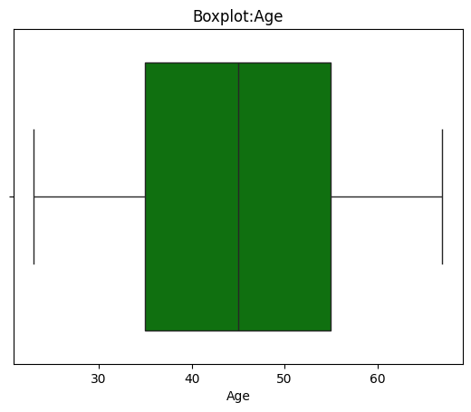

```python
plt.title('Boxplot:Age')
plt.xlabel('Age')
sns.axes_style('whitegrid')
sns.boxplot(data=Ploan, x='Age',color='green');
```

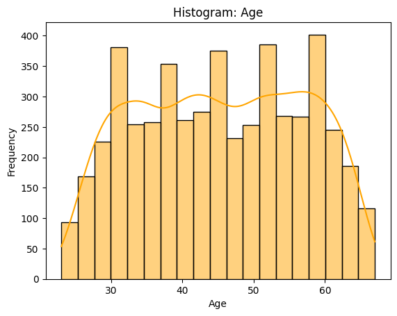

```python
plt.title('Histogram: Age')
plt.xlabel('Age')
plt.ylabel('Frequency')
sns.histplot(data=Ploan, x='Age',color='orange', kde='True');
```

- The age distribution is roughly uniform between ages 30 to 60, with a drop at both extremes.
- Slight concentration around 30, 40, and 60.
- Insight: Products should be tailored more broadly, but with specific offers around early 30s and late 50s—the common customer ages.

#### Observations on Experience

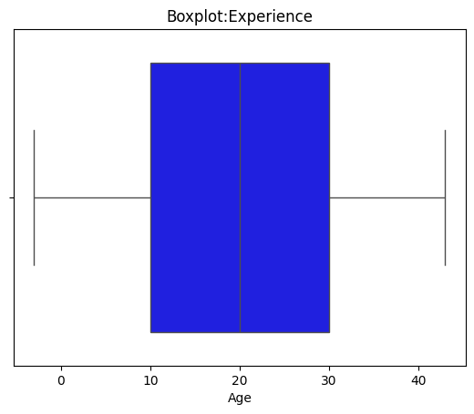

```python
plt.title('Boxplot:Experience')
plt.xlabel('Age')
sns.axes_style('whitegrid')
sns.boxplot(data=Ploan, x='Experience',color='blue');
```

- There are no outliers for the Experince
- 50% of the professional experince of the customer lies between 10 to 30 years
- 75% of the professional experince of the customer is less than around 30 years
- 25% of the professional experince of the customer is below 10 years
- Median of the professional experince of the customer is 20 years

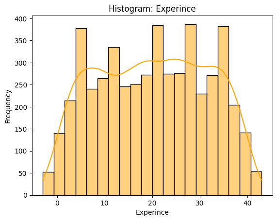

```python
plt.title('Histogram: Experince')
plt.xlabel('Experince')
plt.ylabel('Frequency')
sns.histplot(data=Ploan, x='Experience',color='orange', kde='True');
```

- Experience is somewhat symmetrically distributed, peaking around 5–10, 20–25, and 35–40 years.
- A smooth KDE curve shows balanced representation.

#### Observations on Income

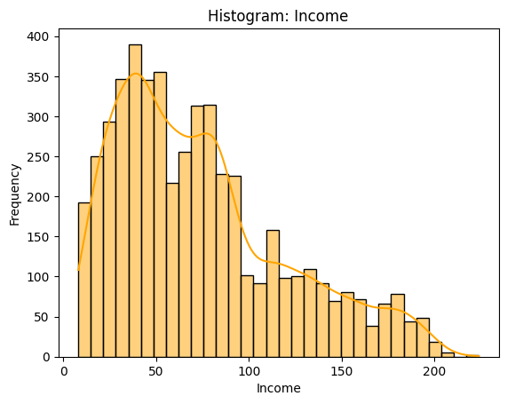

```python
plt.title('Histogram: Income')
plt.xlabel('Income')
plt.ylabel('Frequency')
sns.histplot(data=Ploan, x='Income',color='orange', kde='True');
```

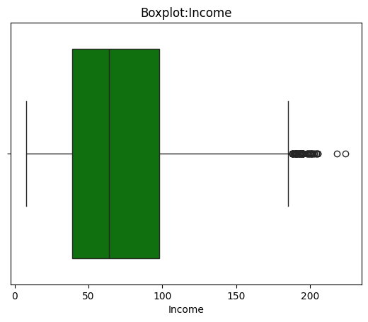

```python
plt.title('Boxplot:Income')
plt.xlabel('Income')
sns.axes_style('whitegrid')
sns.boxplot(data=Ploan, x='Income',color='green');
```

#### Observations on ZIPCode

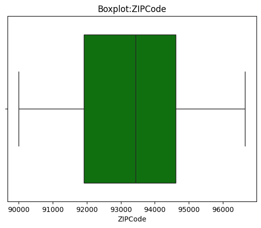

```python
plt.title('Boxplot:ZIPCode')
plt.xlabel('ZIPCode')
sns.axes_style('whitegrid')
sns.boxplot(data=Ploan, x='ZIPCode',color='green');
```

Observations:

- There are no outliers for the ZIP Code
- 50% of the home address ZIP Code lies between around 91900 to 94600
- 75% of the home address ZIP Code is less than around 94600
- 25% of the home address ZIP Code is below 91900
- Median home address ZIP Code is around 93400

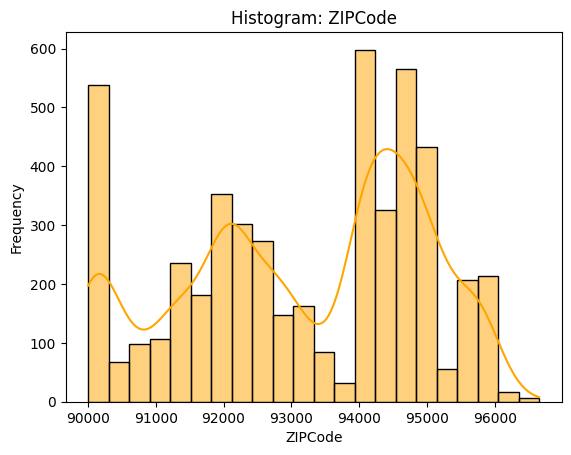

```python
plt.title('Histogram: ZIPCode')
plt.xlabel('ZIPCode')
plt.ylabel('Frequency')
sns.histplot(data=Ploan, x='ZIPCode',color='orange', kde='True');
```

- The home address with ZIPCode ranging from 94000 to 95000 and 90100 have relatively high frequency of customers compared to customers from other ZIPcode.

#### Observations on Family

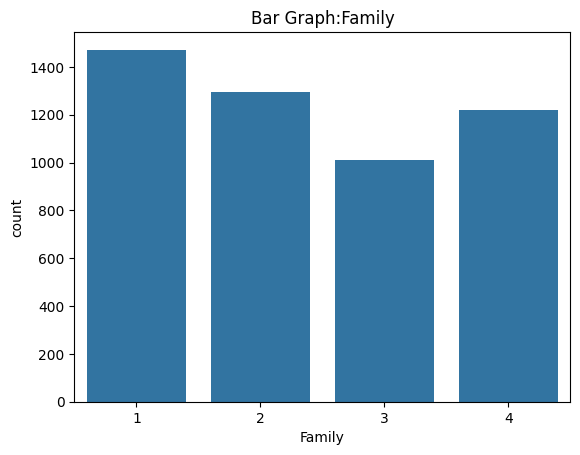

```python
plt.title('Bar Graph:Family')
sns.countplot(data=Ploan, x='Family');
#plt.xticks(rotation=90)
```

- The majority of customers belong to family size 1, with over 1400 members, and the least number are from family size 3.

#### Observations on CCAvg

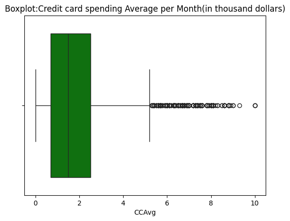

```python
plt.title('Boxplot:Credit card spending Average per Month(in thousand dollars)')
plt.xlabel('CCAvg')
sns.axes_style('whitegrid')
sns.boxplot(data=Ploan, x='CCAvg',color='green');
```

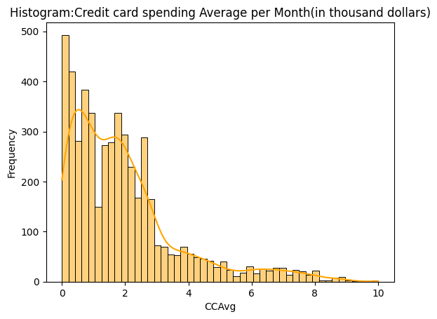

```python
plt.title('Histogram:Credit card spending Average per Month(in thousand dollars)')
plt.xlabel('CCAvg')
plt.ylabel('Frequency')
sns.histplot(data=Ploan, x='CCAvg',color='orange', kde='True');
```

#### Observations on Education

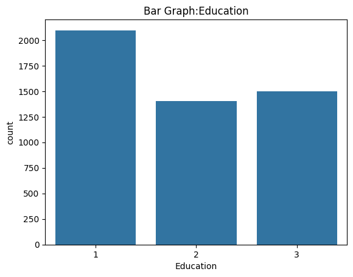

```python
plt.title('Bar Graph:Education')
sns.countplot(data=Ploan, x='Education');
```

- Undergraduates account for the highest number of customers, followed in order by professionals and graduates.

#### Observations on Mortgage

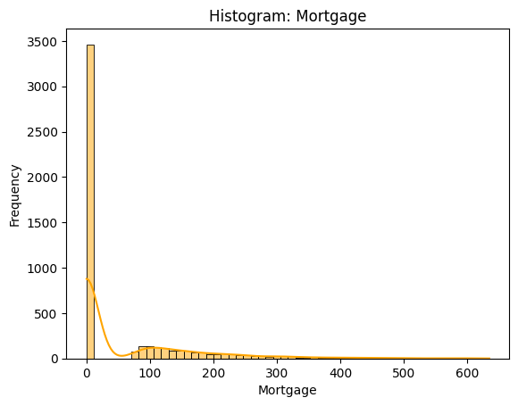

```python
plt.title('Histogram: Mortgage')
plt.xlabel('Mortgage')
plt.ylabel('Frequency')
sns.histplot(data=Ploan, x='Mortgage',color='orange', kde='True');
```

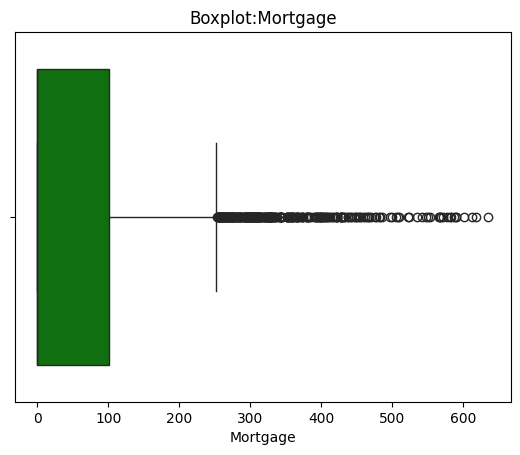

```python
plt.title('Boxplot:Mortgage')
plt.xlabel('Mortgage')
sns.axes_style('whitegrid')
sns.boxplot(data=Ploan, x='Mortgage',color='green');
```

- The morgage graph is highly right skewed indicating possible outlies in upper whisker
- box plot shows lot of outliers on upper whisker side
- 50% of morgage lies between 0 to 100

#### Observations on Personal Loan

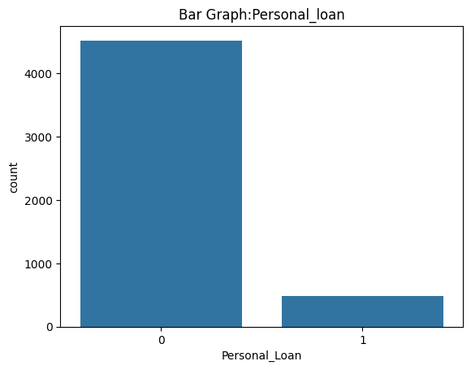

```python
plt.title('Bar Graph:Personal_loan')
sns.countplot(data=Ploan, x='Personal_Loan');
```

- Majority of Customers Have Not Taken a Personal Loan offered in last campaign.The bar labeled 0 (representing customers without a personal loan) is the tallest, with a count of over 4,000.
- Smaller Group of Customers Have Taken Personal Loans.The bar labeled 1 (representing customers with a personal loan) is significantly shorter, with fewer than 1,000 customers.

#### Observations on Securities Account

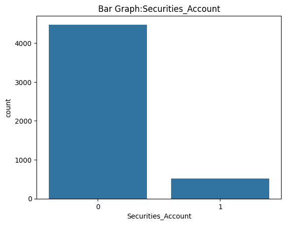

```python
plt.title('Bar Graph:Securities_Account')
sns.countplot(data=Ploan, x='Securities_Account');
```

- Majority of Customers Do Not Have a Securities Account. The bar corresponding to 0 (representing customers without a securities account) has the highest count, exceeding 4,000 customers
- Very Few Customers Have a Securities Account. The bar corresponding to 1 (representing customers with a securities account) is significantly shorter, with fewer than 1,000 customers.

#### Observations on CD_Account

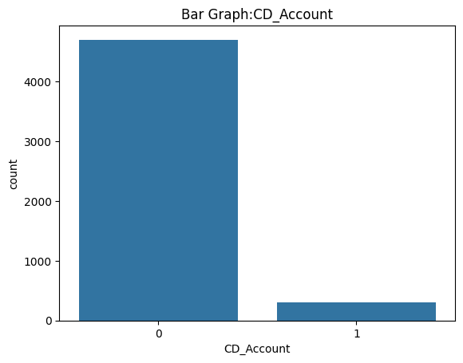

```python
plt.title('Bar Graph:CD_Account')
sns.countplot(data=Ploan, x='CD_Account');
```

- Majority of Customers Do Not Have a CD Account.The bar labeled 0 (representing customers without a Certificate of Deposit (CD) account) has the highest count — well over 4,000 customers.
- Very Few Customers Have a CD Account. The bar labeled 1 (representing customers with a CD account) is much shorter, with fewer than 500 customers.

#### Observations on Online

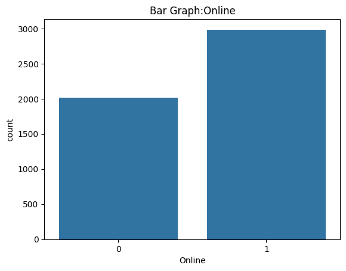

```python
plt.title('Bar Graph:Online')
sns.countplot(data=Ploan, x='Online');
```

- More Customers Use Online Banking Services. The bar labeled 1 (customers using online banking) is taller, with a count close to 3,000.This shows that online banking adoption is strong among the bank's customers.
- A Significant Number Still Do Not Use Online Services. The bar labeled 0 (customers not using online banking) also represents a substantial group, with about 2,000 customers.This indicates that a sizable portion still relies on offline or traditional banking methods.

#### Observations on Credit Card

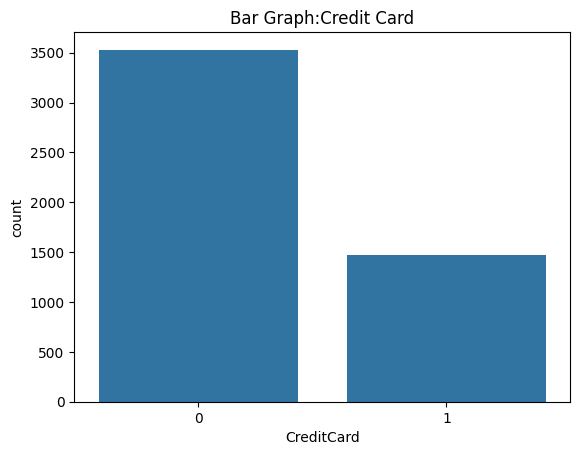

```python
plt.title('Bar Graph:Credit Card')
sns.countplot(data=Ploan, x='CreditCard');
```

1. Majority of Customers Do Not Have a Credit Card.The bar labeled 0 (customers without a credit card) is the tallest, with a count of approximately 3,500.This indicates that a large segment of customers do not use credit cards, either by choice or due to ineligibility. 2.Smaller Proportion Owns Credit Cards.The bar labeled 1 (customers with a credit card) shows a count of about 1,500.Only a minority of customers are using credit cards issued by other than Alll Life bank.

#### Observations on ID

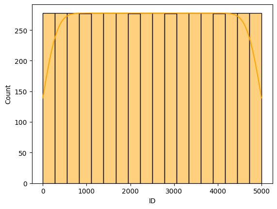

```python
sns.histplot(data=data, x='ID',color='orange', kde='True');
```

ID is unique to customer hence it doesnt yield much valuable information.